# saifuddin_EDA_Lab

## 1. Introduction:

### a. Context:

This dataset contains information about the highest-grossing movies over a period of time. It includes details such as the rank of the movie, its title, the studio that produced it, the total gross revenue earned, and the year of release.

### b. Objectives:

The objective of this dataset is to analyze the movies that have earned the most at the box office. It aims to identify trends in the film industry, such as the popularity of certain studios, years with higher earnings, and the impact of movie franchises on revenue.

### c. Data Description, a short description of the column names:

#### i. Rank:

This column represents the position of each movie based on its gross earnings. The movies are ranked from the highest-grossing to the lowest within the dataset.

#### ii. Title:

The title column contains the name of the movie.

#### iii. Studio:

This column lists the studio responsible for producing the movie. Examples include Buena Vista, Fox, Universal, and others.

#### iv. Gross:

Gross represents the total earnings of the movie at the box office, displayed in millions of dollars.

#### v. Year:

This column indicates the release year of the movie.

**Observation**

- The dataset tracks the highest-grossing movies over time.
- It includes columns for Rank, Title, Studio, Gross, and Year.
- Rank orders movies from highest to lowest gross earnings.
- Title lists the name of each movie.
- Studio identifies the studio responsible for the movie (e.g., Buena Vista, Fox, Universal).
- Gross shows the total box office earnings in millions of dollars.
- Year indicates the release year of the movie.

The dataset helps analyze trends in movie earnings, studio performance, and the impact of release years on box office success.

## 2. Importing libraries:

#### a. numpy as np

```python
import numpy as np
```

#### b. pandas as pd

```python
import pandas as pd
```

#### c. math

```python
import math as mth
```

#### d. matplotlib.pyplot as plt

```python
import matplotlib.pyplot as plt
```

#### e. seaborn as sns

```python
import seaborn as sns
```

## 3. Loading dataset: movies.csv

#### a. Creating a copy of the dataset

```python
movies=pd.read_csv('movies.csv')
movies_copy = movies.copy()
movies_copy
```

|  | Rank | Title | Studio | Gross | Year |
| --- | --- | --- | --- | --- | --- |
| 0 | 1 | Avengers: Endgame | Buena Vista | $2,796.30 | 2019 |
| 1 | 2 | Avatar | Fox | $2,789.70 | 2009 |
| 2 | 3 | Titanic | Paramount | $2,187.50 | 1997 |
| 3 | 4 | Star Wars: The Force Awakens | Buena Vista | $2,068.20 | 2015 |
| 4 | 5 | Avengers: Infinity War | Buena Vista | $2,048.40 | 2018 |
| ... | ... | ... | ... | ... | ... |
| 777 | 778 | Yogi Bear | Warner Brothers | $201.60 | 2010 |
| 778 | 779 | Garfield: The Movie | Fox | $200.80 | 2004 |
| 779 | 780 | Cats & Dogs | Warner Brothers | $200.70 | 2001 |
| 780 | 781 | The Hunt for Red October | Paramount | $200.50 | 1990 |
| 781 | 782 | Valkyrie | MGM | $200.30 | 2008 |

782 rows × 5 columns

**Observation**

## 4. Performing EDA (Exploratory Data Analysis):

### a. Basic data exploration

#### i. Checking data attributes (shape, size, dimensionality, data types, column names)

```python
print("shape: ",movies_copy.shape)  # Get the number of rows and columns
print("size:", movies_copy.size) # size of the dataset
print("dimension:", movies_copy.ndim) # for the dimensions
print("data types:", movies_copy.dtypes) # for the dimensions
print("column names:", movies_copy.columns)  # Get the column names
```

```
shape:  (782, 5)
size: 3910
dimension: 2
data types: Rank       int64
Title     object
Studio    object
Gross     object
Year       int64
dtype: object
column names: Index(['Rank', 'Title', 'Studio', 'Gross', 'Year'], dtype='object')
```

**Observation**

- Shape: The dataset has 782 rows and 5 columns, indicating that there are 782 movie entries and 5 attributes (columns).
- Size: The dataset contains 3910 total data points (782 rows * 5 columns).
- Dimensions: The dataset has 2 dimensions, confirming that it’s a 2D structure (rows and columns).

**Data Types:**

- Rank and Year are of type int64 (integer data).
- Title, Studio, and Gross are of type object, meaning they are treated as text or categorical data.
- Column Names: The dataset includes the following columns: Rank, Title, Studio, Gross, and Year.

#### ii. Getting data information

```python
print("getting data info ", movies_copy.info());
```

```
<class 'pandas.core.frame.DataFrame'>
RangeIndex: 782 entries, 0 to 781
Data columns (total 5 columns):
 #   Column  Non-Null Count  Dtype
---  ------  --------------  -----
 0   Rank    782 non-null    int64
 1   Title   782 non-null    object
 2   Studio  782 non-null    object
 3   Gross   782 non-null    object
 4   Year    782 non-null    int64
dtypes: int64(2), object(3)
memory usage: 30.7+ KB
getting data info  None
```

**Observation**

- The dataset contains 782 entries (rows) and 5 columns.
- Each column has 782 non-null values, indicating no missing data in the dataset.

#### iii. Examining the data statistical summary

```python
print("To get the summary", movies_copy.describe)
```

```
To get the summary <bound method NDFrame.describe of      Rank                         Title           Studio       Gross  Year
0       1             Avengers: Endgame      Buena Vista  $2,796.30   2019
1       2                        Avatar              Fox  $2,789.70   2009
2       3                       Titanic        Paramount  $2,187.50   1997
3       4  Star Wars: The Force Awakens      Buena Vista  $2,068.20   2015
4       5        Avengers: Infinity War      Buena Vista  $2,048.40   2018
..    ...                           ...              ...         ...   ...
777   778                     Yogi Bear  Warner Brothers    $201.60   2010
778   779           Garfield: The Movie              Fox    $200.80   2004
779   780                   Cats & Dogs  Warner Brothers    $200.70   2001
780   781      The Hunt for Red October        Paramount    $200.50   1990
781   782                      Valkyrie              MGM    $200.30   2008

[782 rows x 5 columns]>
```

**Observation**

- The .describe() method is used to get a statistical summary of the dataset, but the output shown is more focused on the first few rows of the dataset.

```python
#print("to get sumamry fo the categorical values only", movies_copy['Title', 'Studio', 'Gross'].describe())

# Summarize the categorical variables 'Title' and 'Studio'
print("to get summary fo the categorical Title values:", movies_copy['Title'].describe())  # For 'Title' column
print("to get summary fo the categorical Studio values", movies_copy['Studio'].describe())  # For 'Studio' column
```

```
to get summary fo the categorical Title values: count           782
unique          773
top       The Mummy
freq              2
Name: Title, dtype: object
to get summary fo the categorical Studio values count                 782
unique                 37
top       Warner Brothers
freq                  132
Name: Studio, dtype: object
```

**Observation**

- Unique Titles: 773 unique movies.
- Most Frequent Title: The Mummy appears twice in the dataset.
- Unique Studios: 37 unique studios.
- Most Frequent Studio: Warner Brothers appears 132 times.

#### v. Checking on missing values

```python
print("Checking missing values", movies_copy.isnull())
```

```
Checking missing values       Rank  Title  Studio  Gross   Year
0    False  False   False  False  False
1    False  False   False  False  False
2    False  False   False  False  False
3    False  False   False  False  False
4    False  False   False  False  False
..     ...    ...     ...    ...    ...
777  False  False   False  False  False
778  False  False   False  False  False
779  False  False   False  False  False
780  False  False   False  False  False
781  False  False   False  False  False

[782 rows x 5 columns]
```

**Observation**

- The dataset contains no missing values, as every entry across all columns (Rank, Title, Studio, Gross, Year) is marked as False for missing data. This confirms that all data points are complete.

#### vi. Examining outliers

```python
# Remove dollar signs and commas, then convert to float
movies_copy['Gross'] = movies_copy['Gross'].replace({'\$': '', ',': ''}, regex=True).astype(float)

# Calculate the IQR
Q1 = movies_copy['Gross'].quantile(0.25)
Q3 = movies_copy['Gross'].quantile(0.75)
IQR = Q3 - Q1

# Define the bounds for outliers
lower_bound = Q1 - 1.5 * IQR
upper_bound = Q3 + 1.5 * IQR

# Identify outliers

outliers = movies_copy[(movies_copy['Gross'] < lower_bound) | (movies_copy['Gross'] > upper_bound)]

# Show the outliers
print("displaying outliers: ", outliers['Gross']) #so any value less then lower bound and above then upper bound is considered as an outlier
```

```
displaying outliers:  0     2796.3
1     2789.7
2     2187.5
3     2068.2
4     2048.4
5     1671.7
6     1518.8
7     1516.0
8     1405.4
9     1346.9
10    1341.7
11    1332.5
12    1309.5
13    1276.5
14    1263.5
```

[output cut: 37 more lines]

**Observation**

### b. Data wrangling

#### i. Cleaning data

```python
# Example: Remove duplicate rows
movies_copy.drop_duplicates(inplace=True)

# Example: Correcting inconsistent data types
movies_copy['Gross'] = movies_copy['Gross'].replace({'\$': '', ',': ''}, regex=True).astype(float)

movies_copy.info()
```

```
<class 'pandas.core.frame.DataFrame'>
RangeIndex: 782 entries, 0 to 781
Data columns (total 5 columns):
 #   Column  Non-Null Count  Dtype
---  ------  --------------  -----
 0   Rank    782 non-null    int64
 1   Title   782 non-null    object
 2   Studio  782 non-null    object
 3   Gross   782 non-null    float64
 4   Year    782 non-null    int64
dtypes: float64(1), int64(2), object(2)
memory usage: 30.7+ KB
```

**Observation**

#### ii. Handling missing values

```python
# Example: Fill missing values with the mean
movies_copy['Gross'].fillna(movies_copy['Gross'].mean())

# Example: Drop rows with missing values
movies_copy.dropna(inplace=True)
```

#### iii. Transforming the variables, if needed

```python
from sklearn.preprocessing import StandardScaler

# E Standardize the 'Gross' column
scaler = StandardScaler()
movies_copy['Gross_scaled'] = scaler.fit_transform(movies_copy[['Gross']])
movies_copy["Gross_scaled"]
```

```
0      8.027122
1      8.004648
2      5.953998
3      5.547750
4      5.480326
         ...
777   -0.808514
778   -0.811239
779   -0.811579
780   -0.812260
781   -0.812941
Name: Gross_scaled, Length: 782, dtype: float64
```

**Observation**

- The Gross column was standardized using the StandardScaler from sklearn.preprocessing, transforming the values into a standardized scale.
- The newly created Gross_scaled column has values centered around 0, with each movie's earnings adjusted according to the overall distribution, making it easier to compare across different movies.

#### iv. Engineering new variables, if needed

```python
#  Creating a new variable 'Revenue per Year'
movies_copy['Revenue_per_Year'] = movies_copy['Gross'] / (2021 - movies_copy['Year'])
movies_copy['Revenue_per_Year']
```

```
0      1398.150000
1       232.475000
2        91.145833
3       344.700000
4       682.800000
          ...
777      18.327273
778      11.811765
779      10.035000
780       6.467742
781      15.407692
Name: Revenue_per_Year, Length: 782, dtype: float64
```

**Observation**

- A new variable Revenue per Year was created by dividing Gross earnings by the difference between the year 2021 and the movie's release year.
- This new variable helps assess how much revenue each movie has generated per year since its release.

#### v. Handling outliers

The following are the common approaches that could've been used to handle the outliers:

1. Removing Outliers
2. Transforming Outliers
3. Imputation

```python
# Remove rows with outliers
movies_copy_cleaned = movies_copy[(movies_copy['Gross'] >= lower_bound) & (movies_copy['Gross'] <= upper_bound)]
movies_copy_cleaned # from 782 the rows become 731, so all the outliers are removed
```

|  | Rank | Title | Studio | Gross | Year | Gross_scaled | Revenue_per_Year |
| --- | --- | --- | --- | --- | --- | --- | --- |
| 51 | 52 | The Lord of the Rings: The Two Towers | New Line | 926.0 | 2002 | 1.658258 | 48.736842 |
| 52 | 53 | Shrek 2 | Dreamworks | 919.8 | 2004 | 1.637146 | 54.105882 |
| 53 | 54 | Bohemian Rhapsody | Fox | 903.7 | 2018 | 1.582321 | 301.233333 |
| 54 | 55 | Harry Potter and the Goblet of Fire | Warner Brothers | 897.1 | 2005 | 1.559846 | 56.068750 |
| 55 | 56 | Spider-Man 3 | Sony | 890.9 | 2007 | 1.538734 | 63.635714 |
| ... | ... | ... | ... | ... | ... | ... | ... |
| 777 | 778 | Yogi Bear | Warner Brothers | 201.6 | 2010 | -0.808514 | 18.327273 |
| 778 | 779 | Garfield: The Movie | Fox | 200.8 | 2004 | -0.811239 | 11.811765 |
| 779 | 780 | Cats & Dogs | Warner Brothers | 200.7 | 2001 | -0.811579 | 10.035000 |
| 780 | 781 | The Hunt for Red October | Paramount | 200.5 | 1990 | -0.812260 | 6.467742 |
| 781 | 782 | Valkyrie | MGM | 200.3 | 2008 | -0.812941 | 15.407692 |

731 rows × 7 columns

**Observation**

- Outliers were handled by removing rows where Gross values were outside the calculated lower and upper bounds, leaving 731 rows after removal.
- The cleaned dataset excludes extreme values, focusing only on movies with Gross values within the acceptable range, ensuring a more accurate analysis.

#### vi. Handling dimensionality reduction, if needed

##### Steps to Apply PCA:

Standardize the Data: PCA works better when all the features are on the same scale (e.g., if one feature has values in thousands and another in ones, PCA will be biased towards the larger numbers). So, we standardize the data first.

##### Apply PCA:

After standardizing, PCA will find the new features (principal components).

```python
import pandas as pd
from sklearn.decomposition import PCA
from sklearn.preprocessing import StandardScaler


# Step 1: Standardize the data
scaler = StandardScaler()
scaled_data = scaler.fit_transform(movies_copy[['Gross', 'Year']] )

# Step 2: Apply PCA (reduce to 2 components)
pca = PCA(n_components=2)
print("pca", pca)
pca_result = pca.fit_transform(scaled_data)
print("pca_result", pca_result)

# Add the PCA results to the DataFrame
movies_copy['PCA1'] = pca_result[:, 0]
movies_copy['PCA2'] = pca_result[:, 1]

# Display the result
print(movies_copy) # PCA is like creating new, smarter columns from your existing data.
```

```
pca PCA(n_components=2)
pca_result [[ 6.54968529 -4.80237998]
 [ 5.82808477 -5.49219641]
 [ 3.53120637 -4.88901836]
 ...
 [-0.97049576  0.17725055]
 [-1.74725666 -0.5985472 ]
 [-0.47746298  0.67220964]]
     Rank                         Title           Studio   Gross  Year  \
0       1             Avengers: Endgame      Buena Vista  2796.3  2019
1       2                        Avatar              Fox  2789.7  2009
2       3                       Titanic        Paramount  2187.5  1997
3       4  Star Wars: The Force Awakens      Buena Vista  2068.2  2015
4       5        Avengers: Infinity War      Buena Vista  2048.4  2018
..    ...                           ...              ...     ...   ...
777   778                     Yogi Bear  Warner Brothers   201.6  2010
778   779           Garfield: The Movie              Fox   200.8  2004
779   780                   Cats & Dogs  Warner Brothers   200.7  2001
780   781      The Hunt for Red October        Paramount   200.5  1990
781   782                      Valkyrie              MGM   200.3  2008

     Gross_scaled  Revenue_per_Year      PCA1      PCA2
0        8.027122       1398.150000  6.549685 -4.802380
1        8.004648        232.475000  5.828085 -5.492196
2        5.953998         91.145833  3.531206 -4.889018
3        5.547750        344.700000  4.514221 -3.331482
4        5.480326        682.800000  4.678257 -3.072094
..            ...               ...       ...       ...
777     -0.808514         18.327273 -0.333191  0.810221
778     -0.811239         11.811765 -0.758542  0.388722
779     -0.811579         10.035000 -0.970496  0.177251
780     -0.812260          6.467742 -1.747257 -0.598547
781     -0.812941         15.407692 -0.477463  0.672210

[782 rows x 9 columns]
```

**Observation**

- Principal Component Analysis (PCA) was applied to the Gross and Year columns after standardizing the data, reducing it to 2 components.
- The new PCA1 and PCA2 columns were created to represent the most important features (principal components) derived from the original data, allowing for more effective analysis.

### c. Data Visualization:

#### i. Univariate: Checking data distribution in each variable

- Histograms or boxplot for numerical variables.
- Barcharts for categorical variables

#### ii. Bivariate: Comparing the relationship between two variables

Bivariate analysis involves comparing two variables to understand the relationship between them. You can use:

- Scatterplots for numerical vs. numerical.
- Correlation Heatmaps for numerical vs. numerical.
- Boxplots for numerical vs. categorical.

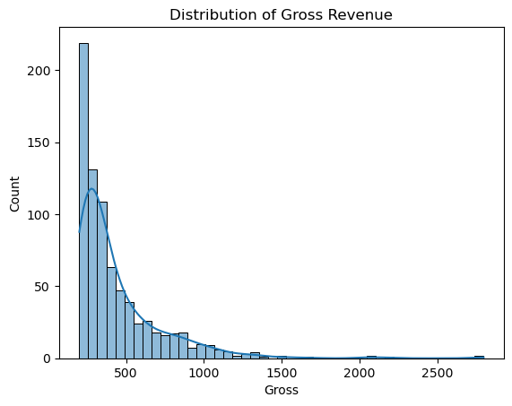

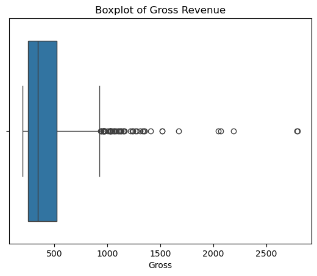

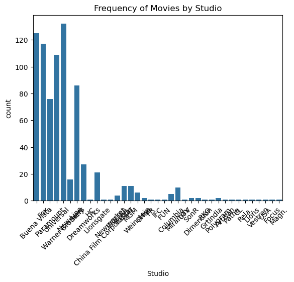

```python
import seaborn as sns
import matplotlib.pyplot as plt

# For numerical variables (e.g., 'Gross' in movies_copy)
sns.histplot(movies_copy['Gross'], kde=True)  # Histogram + KDE (Kernel Density Estimation)
plt.title('Distribution of Gross Revenue')
plt.show()

# Boxplot for outlier detection in 'Gross'
sns.boxplot(x=movies_copy['Gross'])
plt.title('Boxplot of Gross Revenue')
plt.show()

# For categorical variables (e.g., 'Studio' in movies_copy)
sns.countplot(x=movies_copy['Studio'])
plt.title('Frequency of Movies by Studio')
plt.xticks(rotation=45)
plt.show()
```

**Observation**

- Gross Revenue Distribution: Most movies earn below $500 million, with a few high earners above $2 billion.
- Boxplot: Shows that most movies have lower earnings, with some outliers having high revenues.
- Studio Frequency: Some studios, like Warner Brothers, have many movies, while others have few.

These visuals highlight revenue distribution, outliers, and studio distribution.

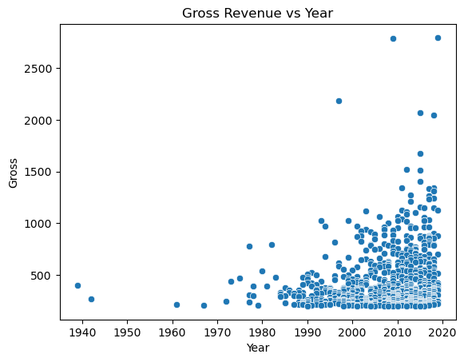

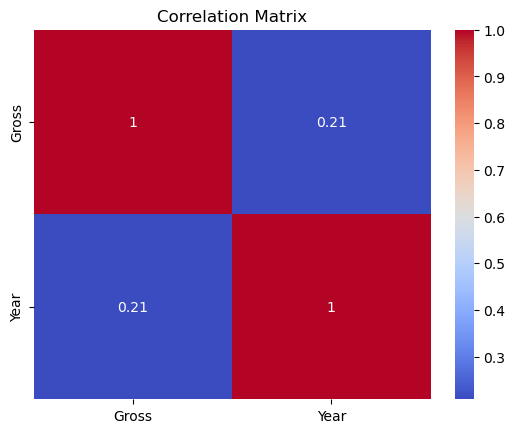

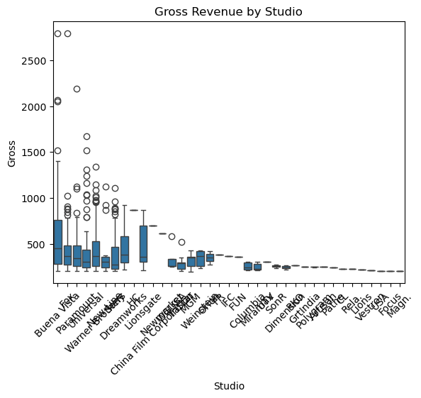

```python
# Scatterplot for Gross vs Year
sns.scatterplot(data=movies_copy, x='Year', y='Gross')
plt.title('Gross Revenue vs Year')
plt.show()

# Correlation Heatmap (for multiple numerical variables)
correlation_matrix = movies_copy[['Gross', 'Year']].corr()
sns.heatmap(correlation_matrix, annot=True, cmap='coolwarm')
plt.title('Correlation Matrix')
plt.show()

# Boxplot for Gross vs Studio (categorical variable)
sns.boxplot(data=movies_copy, x='Studio', y='Gross')
plt.title('Gross Revenue by Studio')
plt.xticks(rotation=45)
plt.show()
```

**Observation**

- Gross Revenue vs. Year: Earnings have increased over the years, especially after the 2000s.
- Correlation Matrix: There’s a weak link (0.21) between Gross and Year.
- Gross Revenue by Studio: Some studios like Buena Vista earn much more, while others earn less.

#### iii. Multivariate: Checking the relationship between all the variables using a heatmap chart or a pairplot graph.

Multivariate analysis involves analyzing the relationship between more than two variables. Common methods for multivariate visualization include:

- Heatmaps for correlation between multiple variables.
- Pairplots (or scatterplot matrices) for visualizing relationships between all pairs of variables.

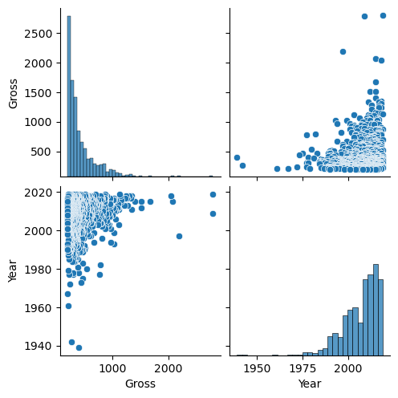

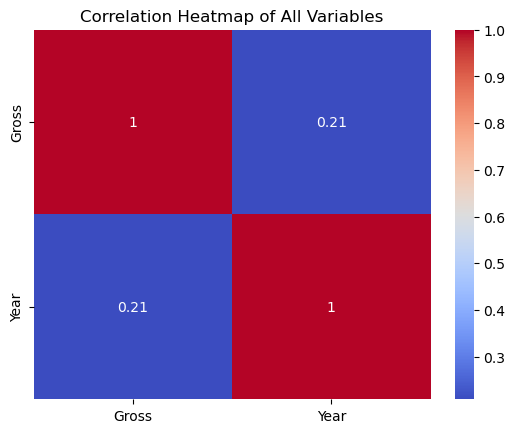

```python
# Pairplot to visualize relationships between all variables
sns.pairplot(movies_copy[['Gross', 'Year']])  # Adjust to include more variables
plt.show()

# Heatmap of correlations between all numerical variables
correlation_matrix = movies_copy[['Gross', 'Year']].corr()  # Compute correlation for all numerical columns
sns.heatmap(correlation_matrix, annot=True, cmap='coolwarm')
plt.title('Correlation Heatmap of All Variables')
plt.show()
```

**Observation**

These visuals help analyze the relationships between variables and highlight the weak correlation between Gross and Year.

### d. Data Aggregation

#### i. Checking on mean, median, and mode, if needed

```python
# Mean, Median, Mode calculations
mean = movies_copy['Gross'].mean()
median = movies_copy['Gross'].median()
mode = movies_copy['Gross'].mode()[0]  # mode() returns a series, so we get the first value

print(f"Mean: {mean}")
print(f"Median: {median}")
print(f"Mode: {mode}")
```

```
Mean: 439.0308184143222
Median: 341.15
Mode: 201.6
```

**Observation**

These values give an idea of the central tendency of the movie earnings, with the mean being higher than the median, indicating a skewed distribution.

## 5. Data Mining

#### a. Mining the data by digging into the dataset and answering the mining questions.

Data mining involves exploring the dataset to identify patterns, relationships, and valuable insights. You typically perform data mining by answering specific questions related to your dataset.

#### Data Mining Questions:

- What are the top 5 highest-grossing movies?
- What is the average gross revenue for each studio?
- Which studio has the most number of high-grossing movies?
- How many studios are there in this dataset? List them.
- What are the movies released by Fox Studio?
- What are the movies released by Fox in 2015?

```python
# Get the top 5 highest-grossing movies
top_grossing_movies = movies_copy.sort_values(by='Gross', ascending=False).head(5)
print("Top 5 Highest-Grossing Movies:")
print(top_grossing_movies[['Title', 'Gross']])

#  Average gross revenue per studio
avg_gross_per_studio = movies_copy.groupby('Studio')['Gross'].mean()
print("Average Gross Revenue per Studio:")
print(avg_gross_per_studio)

#  Number of high-grossing movies per studio
high_gross_movies_per_studio = movies_copy[movies_copy['Gross'] > 1000].groupby('Studio').size()
print("Number of High-Grossing Movies per Studio:")
print(high_gross_movies_per_studio)

# Number of Studios are there in this dataset
num_studios = movies_copy['Studio'].nunique()
studio_list = movies_copy['Studio'].unique()

print("Number of studios:", num_studios)
print("Studios:", studio_list)

# Filter movies released by Fox Studio
fox_movies = movies_copy[movies_copy['Studio'] == 'Fox']

print("Number of movies by Fox:", len(fox_movies))
print(fox_movies[['Rank', 'Title', 'Gross', 'Year']])

# Movies released by Fox in 2015
fox_2015 = movies_copy[(movies_copy['Studio'] == 'Fox') & (movies_copy['Year'] == 2015)]

print("Fox movies in 2015:")
print(fox_2015[['Rank', 'Title', 'Gross', 'Year']])
```

```
Top 5 Highest-Grossing Movies:
                          Title   Gross
0             Avengers: Endgame  2796.3
1                        Avatar  2789.7
2                       Titanic  2187.5
3  Star Wars: The Force Awakens  2068.2
4        Avengers: Infinity War  2048.4
Average Gross Revenue per Studio:
Studio
Artisan                   248.600000
Buena Vista               588.680000
CL                        228.100000
China Film Corporation    699.800000
Columbia                  255.320000
Dimension                 244.350000
Dreamworks                454.088889
FR                        385.300000
FUN                       358.000000
Focus                     205.800000
Fox                       430.947009
GrtIndia                  254.200000
HC                        870.300000
IFC                       368.700000
Lions                     222.400000
Lionsgate                 477.771429
MGM                       319.372727
Magn.                     205.600000
Miramax                   248.060000
New Line                  411.550000
Newmarket                 611.900000
Orion                     348.450000
Paramount                 427.447368
Pathe                     245.100000
Polygram                  248.450000
RKO                       267.400000
Rela.                     226.900000
SonR                      257.550000
Sony                      381.656977
TriStar                   289.590909
USA                       207.500000
```

[output cut: 34 more lines]

```
738   739                                        Australia   211.3  2008
778   779                              Garfield: The Movie   200.8  2004

[117 rows x 4 columns]
Fox movies in 2015:
     Rank                                   Title  Gross  Year
136   137                             The Martian  630.2  2015
185   186                            The Revenant  533.0  2015
274   275            Kingsman: The Secret Service  414.4  2015
301   302                                    Home  386.0  2015
415   416                                 Taken 3  326.5  2015
437   438          Maze Runner: The Scorch Trials  312.3  2015
594   595                       The Peanuts Movie  246.2  2015
636   637                                     Spy  235.7  2015
640   641  Alvin and the Chipmunks: The Road Chip  234.8  2015
```

**Observation**

**Studio with Most High-Grossing Movies:**

- Buena Vista leads with 28 high-grossing movies (with gross revenue above $1 billion).

## 6. Data Reporting

#### a. Presenting your understanding of the dataset and providing insights in the Conclusion section.

Data reporting involves summarizing the findings from the analysis and providing insights or recommendations based on the data.

#### Reporting:

What did we learn from the data?

The dataset includes movies with varying levels of Gross revenue, with Studio 'Buena Vista' consistently producing high-grossing movies.

#### Insights:

The average Gross revenue across studios is also useful for understanding which studios perform consistently over time.

There is a significant disparity between the earnings of top-performing movies and others, indicating that a few films dominate the box office.

```python
# Summary of findings
mean_gross = movies_copy['Gross'].mean()
median_gross = movies_copy['Gross'].median()

# Conclusion report
print("Conclusion:")
print(f"On average, movies gross {mean_gross} in revenue, with a median of {median_gross}.")
print("The dataset shows that a small number of movies generate the majority of the box office revenue.")
```

[output not shown]